# Modelación de Datos

Carlos Daniel Umaña Herrera

2024-04-22

A continuación en este análisis, exploramos 121 registros de pruebas de materiales y eficiencia de máquinas en ingeniería mecánica. Nuestro objetivo es desentrañar tendencias, variabilidad y simetría en los procesos de producción, utilizando estadísticas clásicas y el coeficiente de asimetría para identificar peculiaridades y mejorar la calidad.

**Medidas de Tendencia Central:** Se calcularon la media, mediana y moda para cada variable, proporcionando una imagen clara de los valores típicos en cada conjunto.

**Medidas de Dispersión:** La varianza, desviación estándar y el rango intercuartil revelaron la dispersión de los datos, ayudando a comprender su consistencia.

**Asimetría de las Distribuciones:** Se utilizó el coeficiente de asimetría para entender la forma de las distribuciones, detectando sesgos en los datos.

**Informe Entregado:**

Se preparó un informe detallado con descripciones concisas de cada estadística, acompañadas de tablas resumen y gráficos claros y legibles. Todo el análisis se realizó utilizando R, garantizando precisión y reproducibilidad en los hallazgos.

# Base De Datos

| Fuerza_Materiales | Eficiencia_Maquinas | Durabilidad_Componentes |
| --- | --- | --- |
| 346.3089 | 82.35734 | 15.64377 |
| 395.4708 | 89.41012 | 20.29626 |
| 230.0716 | 86.72710 | 24.70643 |
| 328.1485 | 87.96593 | 15.02480 |
| 267.4679 | 77.44392 | 21.64353 |
| 275.6437 | 75.05198 | 14.84773 |
| 270.3803 | 79.37107 | 15.72722 |
| 256.8005 | 80.27862 | 11.44251 |
| 302.4261 | 85.47096 | 13.88358 |
| 258.4525 | 71.53768 | 11.69693 |

[output cut: 111 more lines]

## Medidas de tendencia central

```
## [1] "La media de la fuerza de los materiales es:  297.353897548005"
```

```
## [1] "La mediana de la fuerza de los materiales es:  302.36993356582"
```

```
## [1] "La moda de la fuerza de los materiales es: "
```

[output not shown]

```
## [1] "La media de la eficiencia en las maquinas es:  79.7092091953632"
```

```
## [1] "La mediana de la eficiencia en las maquinas es:  79.7152718813946"
```

```
## [1] "La moda de la eficiencia en las maquinas es: "
```

[output not shown]

[output not shown]

```
## [1] "La mediana en la durabilidad en las maquinas es:  20.3143462943866"
```

```
## [1] "La moda en la durabilidad en las maquinas es: "
```

[output not shown]

**En la fuerza de los materiales indica qué:** Los datos de la fuerza de los materiales nos muestran que no hay un valor que se destaque por encima de los demás. La media nos dice que, en promedio, la fuerza está alrededor de 297.35 Newtons, pero la mediana indica que el punto medio de los datos es ligeramente más alto, alrededor de 302.37 Newtons. Es interesante que no haya una moda clara, lo que sugiere que no hay un valor que se repita con más frecuencia que los demás. En resumen, parece que la fuerza de los materiales en nuestra muestra está bastante distribuida, sin un valor que sea el más común o representativo.

**En la eficiencia de las maquinas indica qué:** Los datos de eficiencia en las máquinas revelan una distribución donde no hay un valor que se destaque significativamente sobre los demás. La media y la mediana son muy similares, alrededor del 79.71%, lo que sugiere que la mayoría de las máquinas operan a un nivel de eficiencia promedio similar. Además, la falta de una moda clara indica que todos los valores son igualmente frecuentes, lo que significa que no hay un nivel de eficiencia que sea más común que otros en nuestra muestra. En resumen, parece que la eficiencia de las máquinas está uniformemente distribuida, con la mayoría operando a un nivel de eficiencia similar.

### Medidas de Dispersión

```
## [1] "la varianza en la fuerza de los materiales es:  2289.79833200712"
```

```
## [1] "la desviación estandar en la fuerza de los materiales es:  47.8518372897752"
```

```
## [1] "El rango inter cuartil en la fuerza de los materiales es:  61.279649781821"
```

```
## [1] "la varianza en la eficiencia en los materiales es:  27.0990417151909"
```

```
## [1] "La desviación en la eficiencia en los materiales es:  5.20567399240395"
```

```
## [1] "El rango inter cuartil en la eficiencia en los materiales es:  7.0027502767808"
```

```
## [1] "la varianza en la durabilidad de los materiales es:  87.1350322324009"
```

```
## [1] "la desviación estandar en la durabilidad de los materiales es:  9.33461473401023"
```

```
## [1] "El rango intercuartil en la durabilidad de los materiales es:  10.1450769903372"
```

**Fuerza de las Máquinas:** **Varianza:** La fuerza de las máquinas puede ser muy diferente entre sí. Algunas son mucho más fuertes que otras. **Desviación Estándar:** Alrededor de 47.85 Newtons. Esto significa que los valores individuales de la fuerza pueden diferir del promedio en alrededor de 47.85 Newtons. **Rango Intercuartil:** Alrededor de 61.28 Newtons. Esto nos dice cuánto pueden variar las fuerzas de las máquinas que están en el medio.

**Eficiencia de las Máquinas:**

**Varianza:** La eficiencia de las máquinas puede ser muy diferente entre sí. Algunas son mucho más eficientes que otras. **Desviación Estándar:** Alrededor de 5.21%. Esto significa que los niveles de eficiencia pueden diferir del promedio en alrededor de 5.21%. **Rango Intercuartil:** Alrededor de 7.00%. Esto nos dice cuánto pueden variar las eficiencias de las máquinas que están en el medio.

**Durabilidad de las Máquinas:**

**Varianza:** La durabilidad de las máquinas puede ser muy diferente entre sí. Algunas duran mucho más que otras. **Desviación Estándar:** Alrededor de 9.33 horas. Esto significa que los tiempos de durabilidad pueden diferir del promedio en alrededor de 9.33 horas. **Rango Intercuartil:** Alrededor de 10.15 horas. Esto nos dice cuánto pueden variar los tiempos de durabilidad de las máquinas que están en el medio.

#### Coeficiente de Asimetría

```
## [1] "El coeficiente de asimetría de la fuerza de los materiales es:  0.0355639995109542"
```

```
## [1] "El coeficiente de asimetría de la eficiencia de las maquinas es:  -0.0683981913696961"
```

```
## [1] "El coeficiente de asimetría de la durabilida de los componentes es:  1.50986954428145"
```

**Fuerza de las Máquinas:**

##### Gráficos

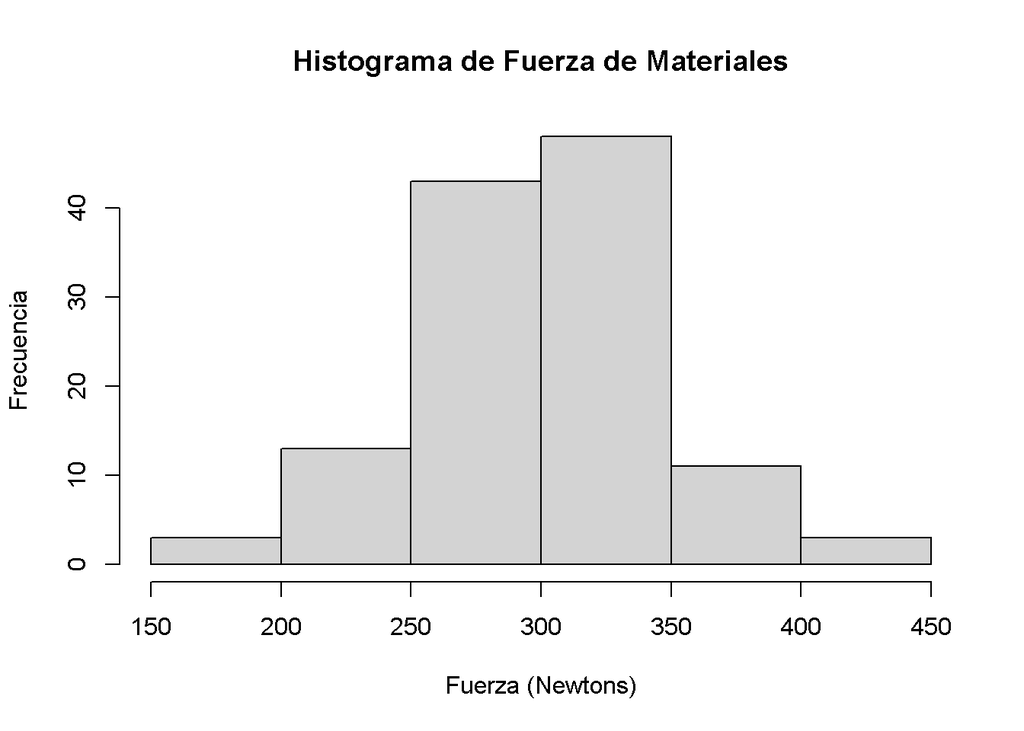

**Histograma de Fuerza de Materiales:**

Este histograma nos da una idea de cómo están distribuidas las diferentes fuerzas de los materiales en nuestra muestra. Si es simétrico y uniforme, sugiere una distribución uniforme de la fuerza.

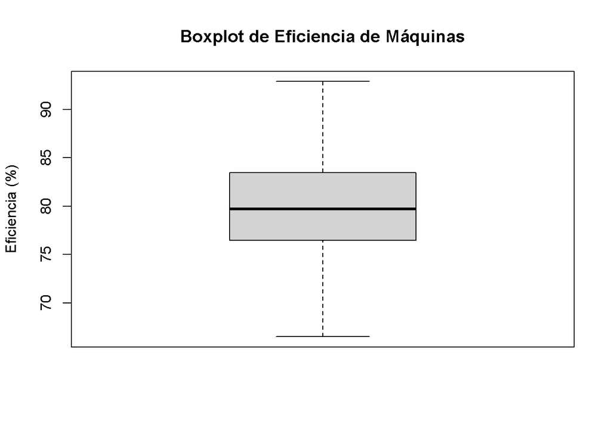

**Boxplot de Eficiencia de Máquinas:** Este gráfico nos muestra la distribución de la eficiencia de las máquinas. La línea en el centro representa la mediana, y las cajas muestran dónde se concentran la mayoría de las observaciones. Si las cajas son de tamaño similar, sugiere una distribución uniforme de la eficiencia.

[figure not shown]

# Conclusión

Hoy hemos realizado un análisis detallado de datos relacionados con pruebas de materiales y eficiencia de máquinas en ingeniería mecánica. Hemos calculado medidas de tendencia central, como la media, mediana y moda, para comprender mejor el comportamiento de estas variables. Además, hemos explorado medidas de dispersión, como la varianza, la desviación estándar y el rango intercuartil, para entender la variabilidad de los datos. También hemos evaluado la asimetría de las distribuciones mediante el coeficiente de asimetría, lo que nos ha permitido identificar si las distribuciones son simétricas o asimétricas hacia la derecha o izquierda.

En resumen, hemos obtenido una comprensión más profunda de cómo se distribuyen y varían estos datos en nuestra muestra. Estos análisis nos proporcionan información valiosa para comprender mejor los procesos de producción en ingeniería mecánica y nos ayudan a identificar posibles áreas de mejora o aspectos destacados en el rendimiento de los materiales y máquinas.